# Hierarchical linear model on fish population trends

Model we are attempting to build:

$$N_{i,t} = f(t, \alpha_i) + g(\lambda_i,
\beta_i) + \varepsilon_i$$

Where:

- $N$ : population size estimate
- $i$ : population
- $t$ : time step
- $f(t, \alpha_i)$ : function estimating the temporal trend in population size
  - $\alpha$: estimated parameter describing each population’s temporal slope
- $g(\lambda, \beta_i)$ : function estimating latent variation in population size
  - $\lambda$ : latent variable (to capture covariation between populations)
  - $\beta$ : estimated parameter describing each population’s latent variation
- $\varepsilon$: residual variation

Because the model also estimates latent variation, we are accounting for the covariation between populations when estimating $N$.

This model then contains key information to calculate and extend an index like the Living Planet Index, to show the average change in population size from a baseline value of 1 in the start year.

The first part of the model estimates the temporal trend of each population’s size ($\alpha_i$), which contains information about population-level change *and* community-level change:

$$\alpha_i \sim N(\mu_{\alpha},
\sigma^2_{\alpha})$$

To calculate the index of change from a baseline of 1 (as in the LPI), the average population trend can then be plugged in to the LPI calculation as follows:

$$I_t = {\mu_{\alpha}}*t + 1$$

This trend can then be visualized and communicated with its known ($\sigma^2_{\alpha}$).

## Setting up

```r
#### import & set up data ####

# from https://github.com/eric-pedersen/groundfish-data-analysis
# note: these are mean biomasses over the whole sampled area with an SE
# not actually raw abundances. But for this purpose, should be ok
load("~/Documents/GitHub/groundfish-data-analysis/data/year_geom_means.Rdata")

time = rownames(Year_Geom_Means_all) %>% as.numeric()

# get number of populations & length of time series
npops <- ncol(Year_Geom_Means_all)
tsl <- nrow(Year_Geom_Means_all)
```

## Building the model with HMSC

```r
# format data
XData <- as.matrix(time)
YData <- as.matrix(Year_Geom_Means_all) %>% apply(2, scale, center = FALSE)
randomEff <- as.factor(1:tsl) # assign a location to pairings of pops

# prepare data
formDat <- as.HMSCdata(X = XData, Y = YData, Random = randomEff, interceptX = TRUE)

# run model
m <- hmsc(formDat,
                family = "gaussian",
                niter = 15000,
                nburn = 5000,
                thin = 5,
                verbose = FALSE)
# save model
saveRDS(m, here("models/hmsc.RDS"))
```

### Model performance

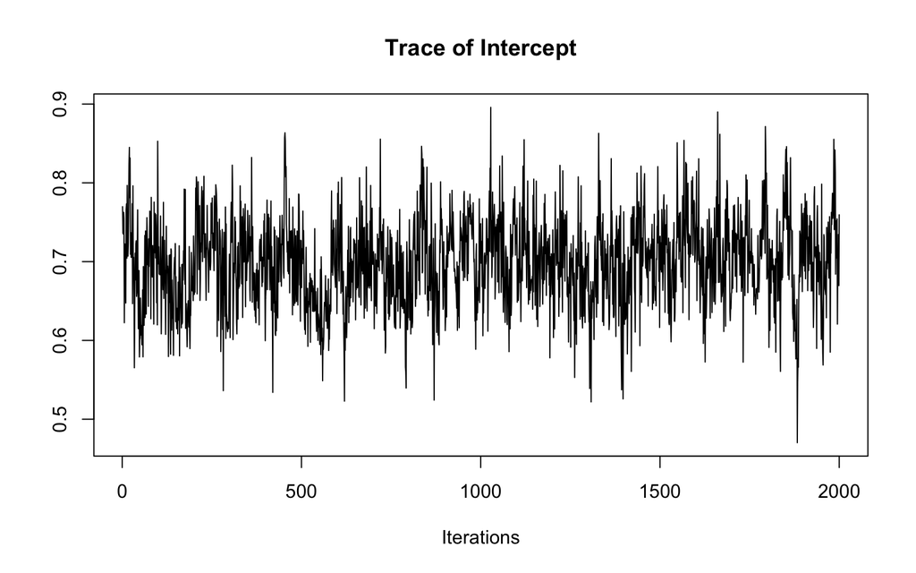

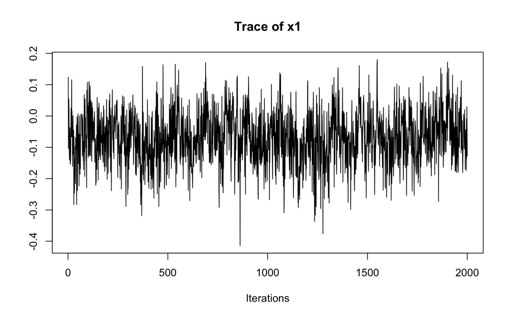

```r
# extract the parameters and format them into an `mcmc` object.
mcmcMeansParamX <- as.mcmc(m, parameters = "meansParamX")

# check for parameter convergence (visually)
traceplot(mcmcMeansParamX)
```

```r
# Explanatory power

# (R2 <- Rsquared(m, averageSp = FALSE))
(R2comm <- Rsquared(m, averageSp = TRUE))
```

```
## [1] 0.7018875
```

## Predicting the full model

```r
# Predict and plot model over time

# prepare and format data
formPredDat = as.HMSCdata(X = XData, Random = randomEff)
```

```
## [1] "'Random' was included into a data.frame"
## [1] "column names were added to 'X'"
## [1] "row names were added to 'X'"
```

```r
# predict population size over time from the model
pred <- predict(m,
                newdata = formPredDat,
                type = "response")
```

```r
# Average N across populations
pred_mean = apply(pred, 1, mean)
pred_sd = apply(pred, 1, sd)
```

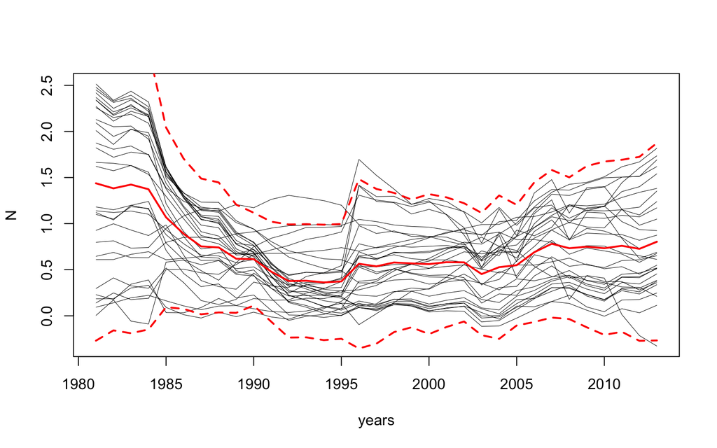

## Extract model coefficients: alpha

```r
# extract the parameters and format them into an `mcmc` object.
coefs = coef(m)
```

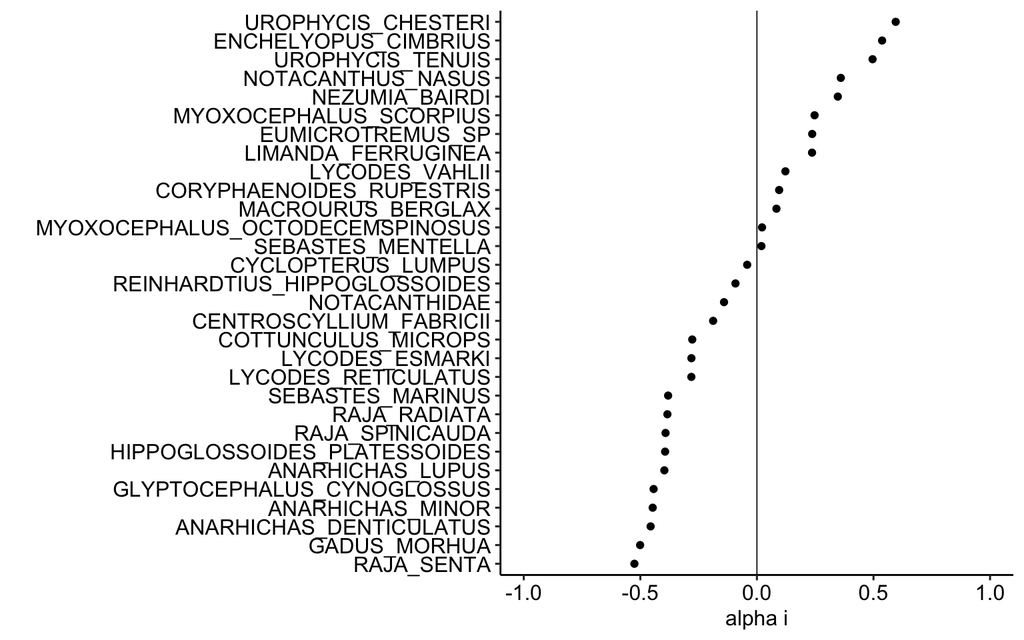

```r
temp = as.data.frame(coefs$paramX)
temp$pop = rownames(temp)
temp$pop <- factor(temp$pop, levels = temp$pop[order(temp$x1)])
ggplot(data = temp) +
  geom_point(aes(y = pop, x = x1)) +
  labs(y = "", x = "alpha i") +
  geom_vline(xintercept = 0, lwd = .3) +
  coord_cartesian(xlim = c(-1, 1))
```

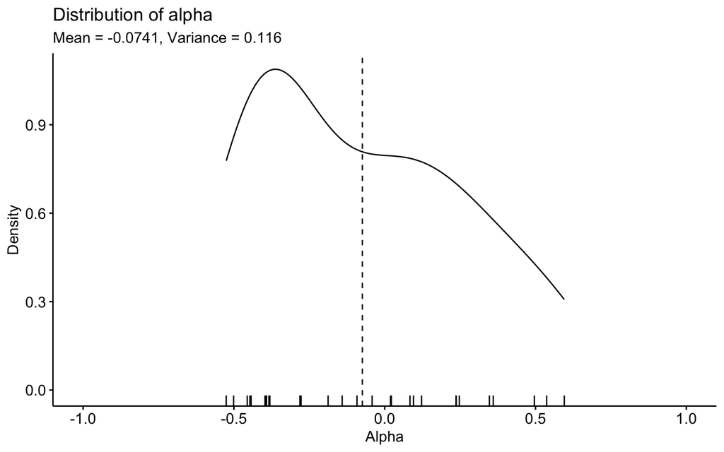

```r
ggdensity(temp, x = "x1", add = "mean", rug = TRUE) +
  coord_cartesian(xlim = c(-1, 1)) +
  labs(title = "Distribution of alpha",
       subtitle = paste0("Mean = ",
                         signif(mean(temp$x1), digits = 3),
                        ", Variance = ",
                        signif(var(temp$x1), digits = 3)),
       y = "Density", x = "Alpha")
```

## Extract covariance between populations

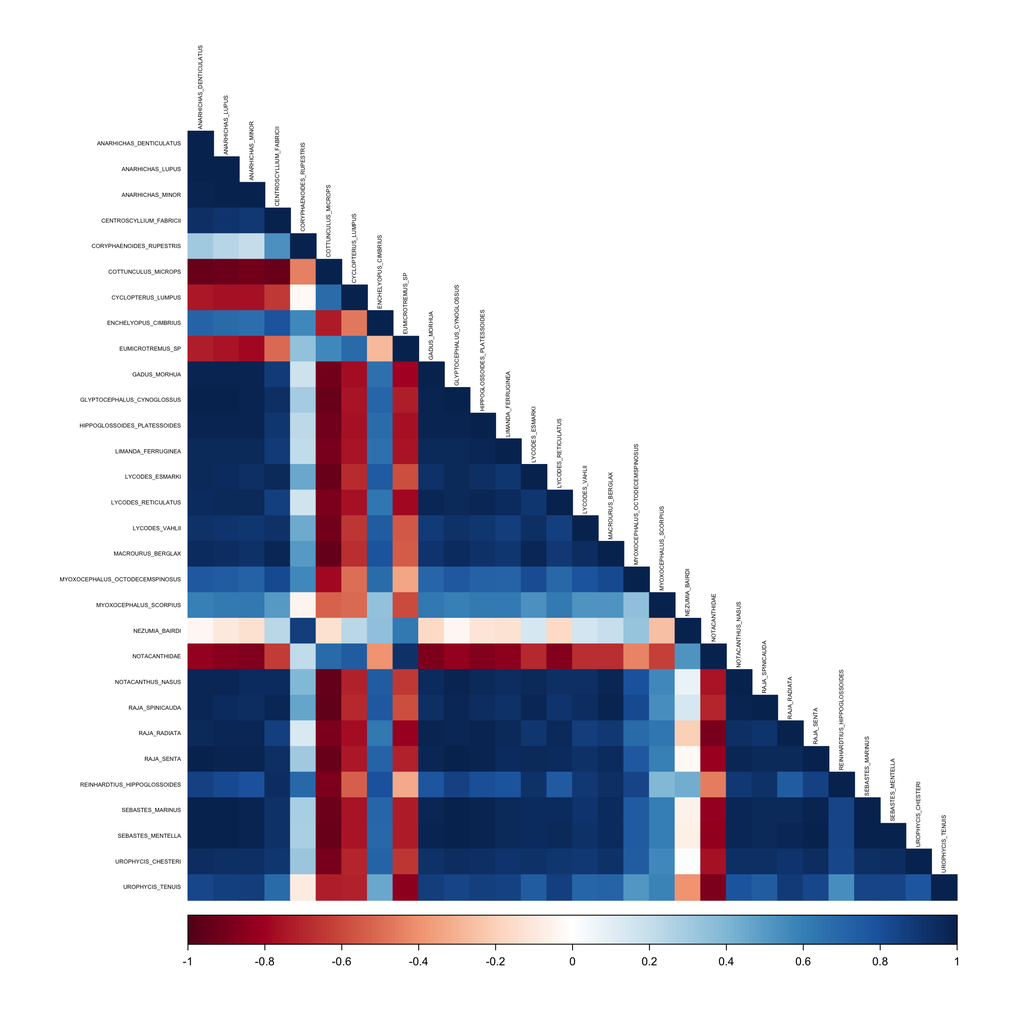

```r
# extract all estimated species-to-species associations matrix
assoMat <- corRandomEff(m)

# Average
siteMean <- apply(assoMat[, , , 1], 1:2, mean)

# Plot as heatmap
corrplot::corrplot(siteMean, type = "lower",
                   method = "color",
                   tl.cex = .4, tl.col = "black")
```

## Extract global population trend

Note: this is *just* the temporal trend, without the latent variation or the residual error.

### Average slope of the temporal trend in population size (LPI-pop)

```r
(lpipop = mean(coefs$paramX[,2]))
```

```
## [1] -0.07412419
```

### Variance in the temporal trend across populations (LPI-comm)

```r
(lpicomm = var(coefs$paramX[,2]))
```

```
## [1] 0.1161826
```

## Compare to LPI

Importing results from the LPI calculated on the same dataset:

```r
rlpi_results <- readRDS("~/Documents/GitHub/hierarchical-lpi/outputs/rlpi_results.rds")
rlpi_results$time <- as.integer(rownames(rlpi_results))
rlpi_results <- rlpi_results[-nrow(rlpi_results),] # remove last value which is negative
```

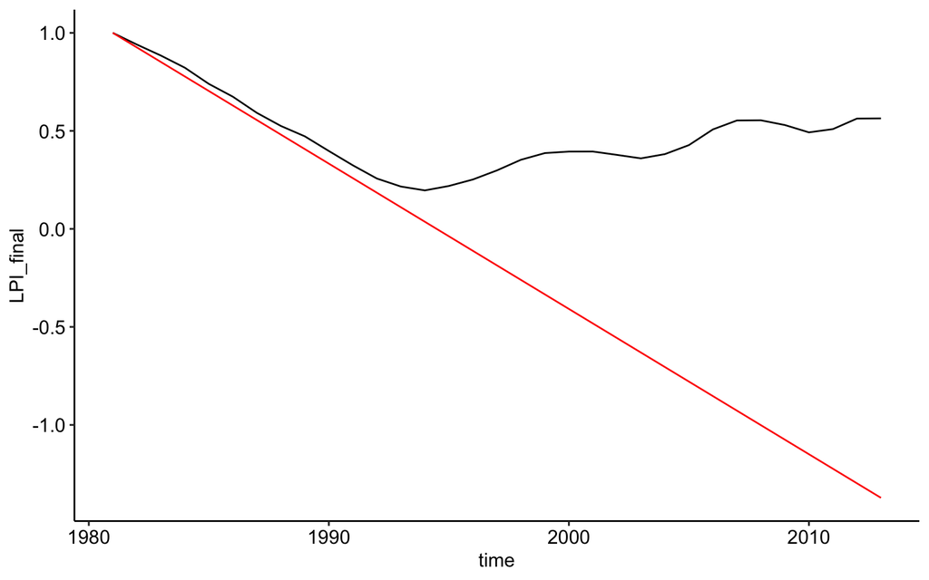

```r
hmsclpi = (time-time[1])*lpipop + 1
ggplot() +
  geom_line(data = rlpi_results, aes(x = time, y = LPI_final)) +
  geom_line(aes(y = hmsclpi, x = time), col = "red")
```